# NOAA Storm Database - severe weather events analysis

## Synopis

This document presents analysis of NOAA ( U.S. National Oceanic and Atmospheric Administration’s) storm database. This database tracks characteristics of major storms and weather events in the United States, including when and where they occur, as well as estimates of any fatalities, injuries, and property damage. The events in the database start in the year 1950 and end in November 2011. In the earlier years of the database there are generally fewer events recorded, most likely due to a lack of good records. More recent years should be considered more complete.

Following below analysis there has been a one imporant outcome, that leads to conclusion, that tornado is by far the most severe event, when it comes to fatality and also the one, that brings the biggest cost implication, when hit.

## Data Processing

1. First, lets download the data, unzip and assign to R placeholder

```r
data_source <- "https://d396qusza40orc.cloudfront.net/repdata%2Fdata%2FStormData.csv.bz2"
data_dest <- paste(getwd(), "/repdata_Fdata_FStormData.csv.bz2", sep = "")
download.file(data_source, data_dest)

data_read <- read.table(data_dest, header = TRUE, sep = ",")
```

At this point, there is no preprocessing of data, and those are loaded in raw form do dataframe for further analysis.

2. Let´s now check how data looks like

```r
head(data_read, 3)
```

```
##   STATE__          BGN_DATE BGN_TIME TIME_ZONE COUNTY COUNTYNAME STATE  EVTYPE
## 1       1 4/18/1950 0:00:00     0130       CST     97     MOBILE    AL TORNADO
## 2       1 4/18/1950 0:00:00     0145       CST      3    BALDWIN    AL TORNADO
## 3       1 2/20/1951 0:00:00     1600       CST     57    FAYETTE    AL TORNADO
##   BGN_RANGE BGN_AZI BGN_LOCATI END_DATE END_TIME COUNTY_END COUNTYENDN
## 1         0                                               0         NA
## 2         0                                               0         NA
## 3         0                                               0         NA
##   END_RANGE END_AZI END_LOCATI LENGTH WIDTH F MAG FATALITIES INJURIES PROPDMG
## 1         0                      14.0   100 3   0          0       15    25.0
## 2         0                       2.0   150 2   0          0        0     2.5
## 3         0                       0.1   123 2   0          0        2    25.0
##   PROPDMGEXP CROPDMG CROPDMGEXP WFO STATEOFFIC ZONENAMES LATITUDE LONGITUDE
## 1          K       0                                         3040      8812
## 2          K       0                                         3042      8755
## 3          K       0                                         3340      8742
##   LATITUDE_E LONGITUDE_ REMARKS REFNUM
## 1       3051       8806              1
## 2          0          0              2
## 3          0          0              3
```

```r
summary(data_read)
```

```
##     STATE__       BGN_DATE           BGN_TIME          TIME_ZONE
##  Min.   : 1.0   Length:902297      Length:902297      Length:902297
##  1st Qu.:19.0   Class :character   Class :character   Class :character
##  Median :30.0   Mode  :character   Mode  :character   Mode  :character
##  Mean   :31.2
##  3rd Qu.:45.0
##  Max.   :95.0
##
##      COUNTY       COUNTYNAME           STATE              EVTYPE
##  Min.   :  0.0   Length:902297      Length:902297      Length:902297
##  1st Qu.: 31.0   Class :character   Class :character   Class :character
##  Median : 75.0   Mode  :character   Mode  :character   Mode  :character
##  Mean   :100.6
##  3rd Qu.:131.0
##  Max.   :873.0
##
##    BGN_RANGE          BGN_AZI           BGN_LOCATI          END_DATE
##  Min.   :   0.000   Length:902297      Length:902297      Length:902297
##  1st Qu.:   0.000   Class :character   Class :character   Class :character
##  Median :   0.000   Mode  :character   Mode  :character   Mode  :character
##  Mean   :   1.484
##  3rd Qu.:   1.000
##  Max.   :3749.000
##
##    END_TIME           COUNTY_END COUNTYENDN       END_RANGE
##  Length:902297      Min.   :0    Mode:logical   Min.   :  0.0000
##  Class :character   1st Qu.:0    NA's:902297    1st Qu.:  0.0000
##  Mode  :character   Median :0                   Median :  0.0000
##                     Mean   :0                   Mean   :  0.9862
##                     3rd Qu.:0                   3rd Qu.:  0.0000
##                     Max.   :0                   Max.   :925.0000
##
##    END_AZI           END_LOCATI            LENGTH              WIDTH
##  Length:902297      Length:902297      Min.   :   0.0000   Min.   :   0.000
##  Class :character   Class :character   1st Qu.:   0.0000   1st Qu.:   0.000
##  Mode  :character   Mode  :character   Median :   0.0000   Median :   0.000
##                                        Mean   :   0.2301   Mean   :   7.503
##                                        3rd Qu.:   0.0000   3rd Qu.:   0.000
##                                        Max.   :2315.0000   Max.   :4400.000
##
```

[output cut: 25 more lines]

```
##  Min.   :-14451   Min.   :   0   Min.   :-14455   Length:902297
##  1st Qu.:  7247   1st Qu.:   0   1st Qu.:     0   Class :character
##  Median :  8707   Median :   0   Median :     0   Mode  :character
##  Mean   :  6940   Mean   :1452   Mean   :  3509
##  3rd Qu.:  9605   3rd Qu.:3549   3rd Qu.:  8735
##  Max.   : 17124   Max.   :9706   Max.   :106220
##                   NA's   :40
##      REFNUM
##  Min.   :     1
##  1st Qu.:225575
##  Median :451149
##  Mean   :451149
##  3rd Qu.:676723
##  Max.   :902297
##
```

## Result

For first question of which event type is most severe when it comes to injured or deadly cases, we will combine both values of “FATALITIES” and “INJURIES” and quantify severeness by sum of both. To do that, we will create yet another variable in a given dataframe by following below transformation code:

```r
data_read <- data_read %>% mutate(FATALITY = FATALITIES + INJURIES)
```

Now, let´s check which event type is most severe. To do that, we will group by EVTYPE and sumarise created variable (FATALITY) and sort descending by number of fatal incidents by runing below code:

```r
data_read_grouped <- data_read %>% group_by(EVTYPE)  %>% summarise(TOTAL_FATAL = sum(FATALITY)) %>% arrange(desc(TOTAL_FATAL))
data_read_grouped_head <- head(data_read_grouped, 5)
```

Let´s see it in a plot:

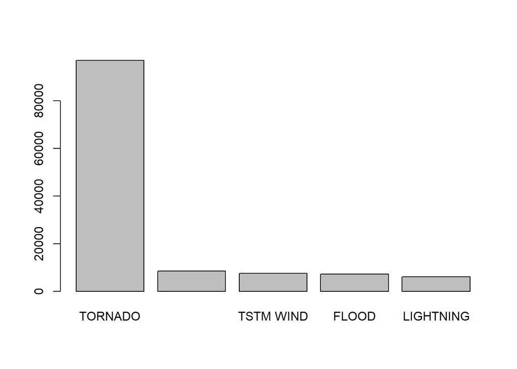

```r
barplot(data_read_grouped_head$TOTAL_FATAL, names.arg = data_read_grouped_head$EVTYPE)
```

Now, for second question, we will try to answer which event brings the biggest cost impact. To do that, we will prepare similar data set as above, however we will sum over TOTAL_DEMAGE

```r
data_read_grouped_dmg <- data_read %>% group_by(EVTYPE)  %>% summarise(TOTAL_DEMAGE = sum(PROPDMG)) %>% arrange(desc(TOTAL_DEMAGE))
data_read_grouped_head_dmg <- head(data_read_grouped_dmg, 5)
```

Again, lets see it in the plot:

[figure not shown]

```r
barplot(data_read_grouped_head_dmg$TOTAL_DEMAGE, names.arg = data_read_grouped_head$EVTYPE, main = "5 top most severe weather events")
```

We can see, that Tornado is by far the most severe type of weather event, causing around 10 times more cases, than next in a row. Similarly, it is also event, that creates the bigest cost impact.